# Rentabilidad de grandes eventos deportivos en el contexto de los paÃses BRICS

## Proporcion de niñas con respecto a niños en educacion primaria y secundaria (%)

### Comparación con un año antes

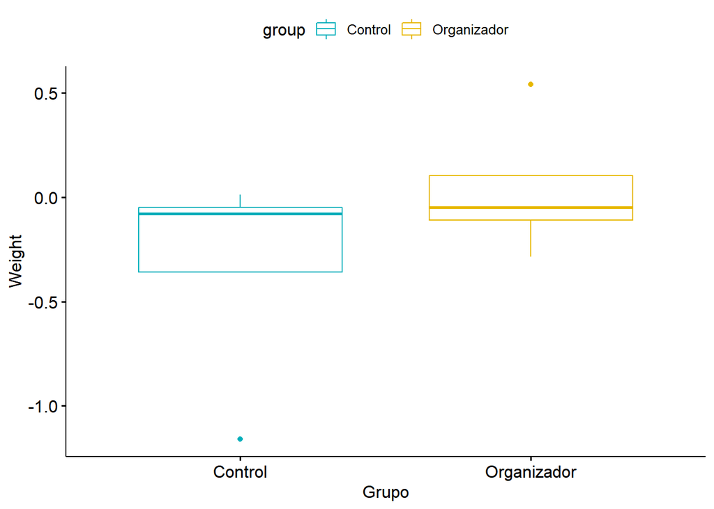

[1] “  
p-valor para un año antes 0.386476230771233” [1] “

### Comparación con un año después

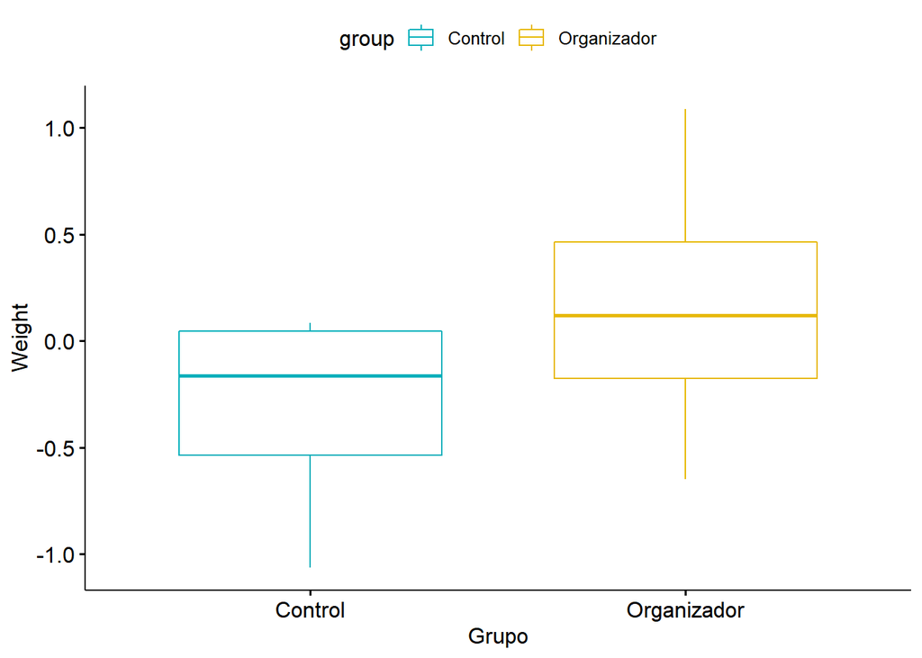

[1] “  
p-valor para un año después 0.386476230771233” [1] “

### Comparación con dos años después

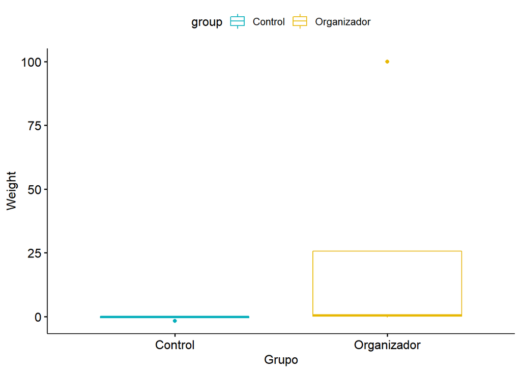

[1] “  
p-valor para dos años después 0.148914673178766” [1] “

### Comparación con un año antes

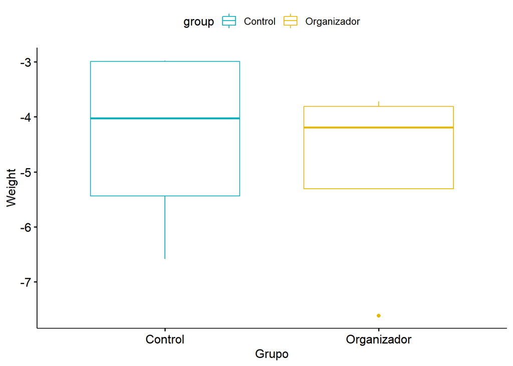

[1] “  
p-valor para un año antes 0.563702861650774” [1] “

### Comparación con un año después

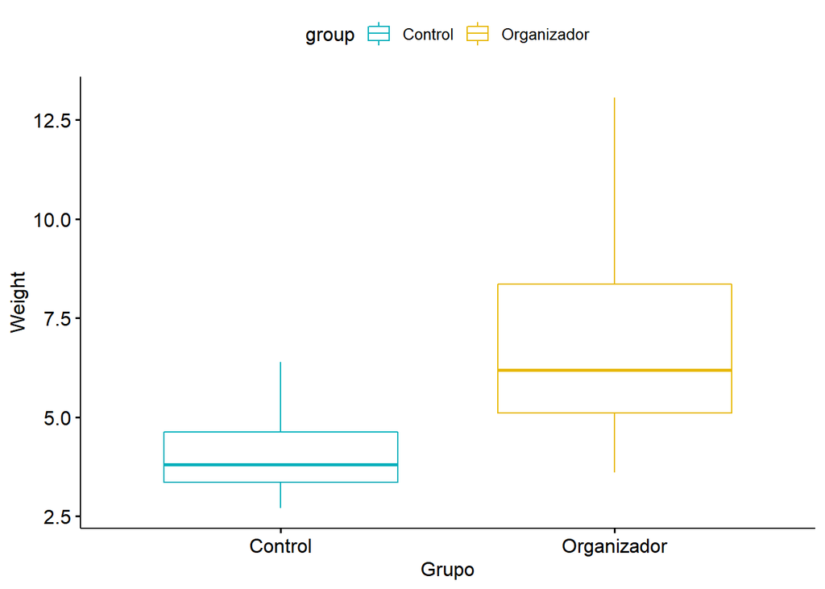

[1] “  
p-valor para un año después 0.148914673178766” [1] “

### Comparación con dos años después

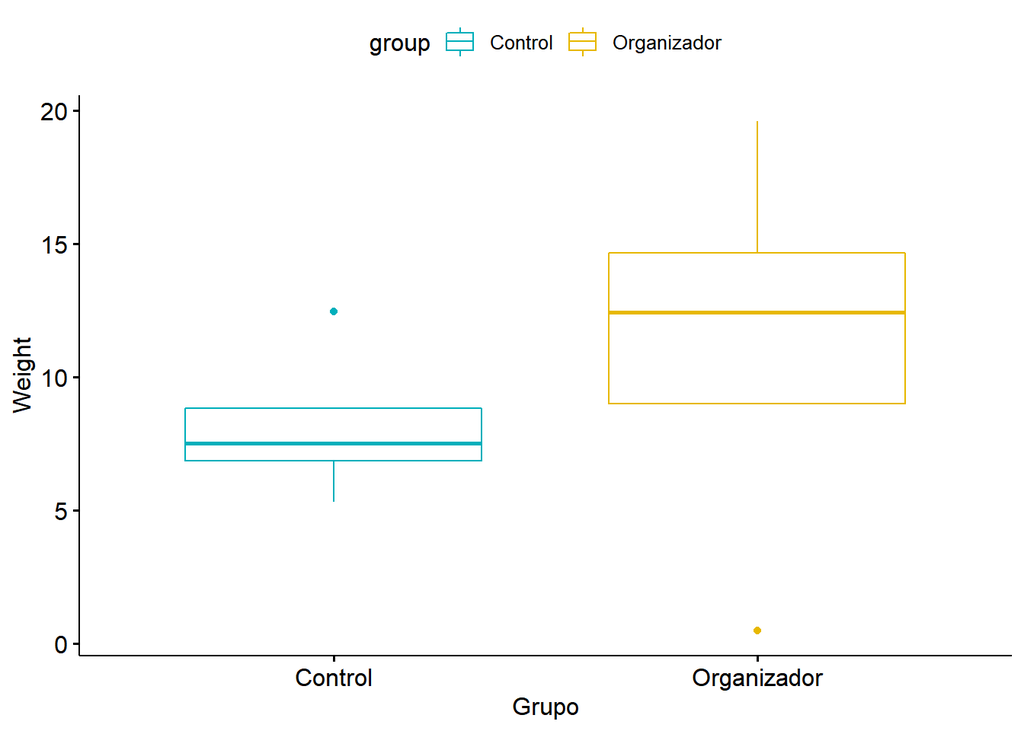

[1] “  
p-valor para dos años después 0.386476230771233” [1] “

## Medicos (por cada 1,000 personas)

### Comparación con un año antes

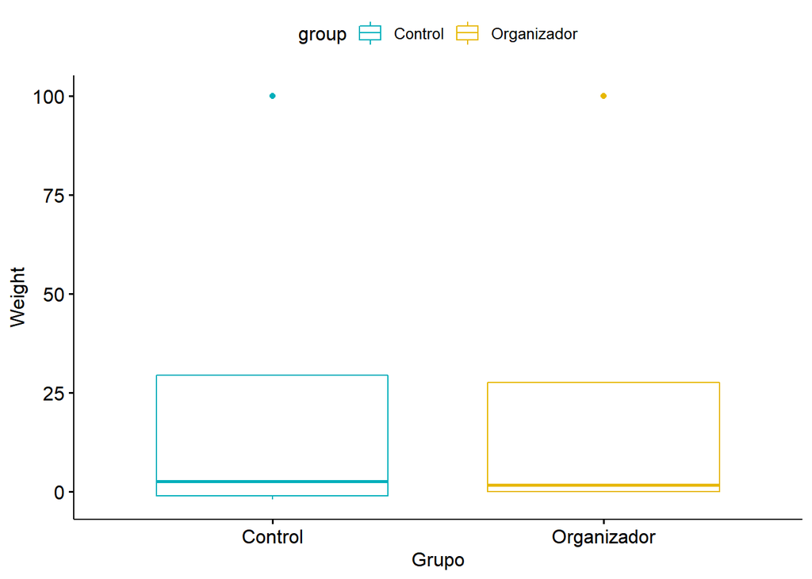

[1] “  
p-valor para un año antes 0.661196707936934” [1] “

### Comparación con un año después

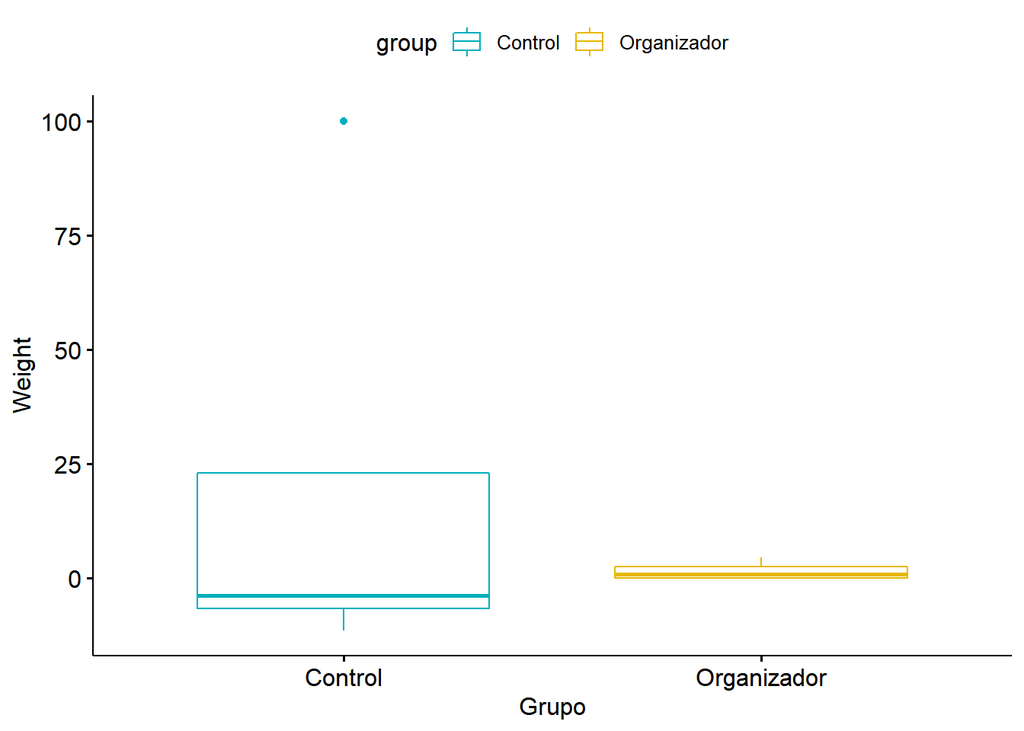

[1] “  
p-valor para un año después 0.245383458473363” [1] “

### Comparación con dos años después

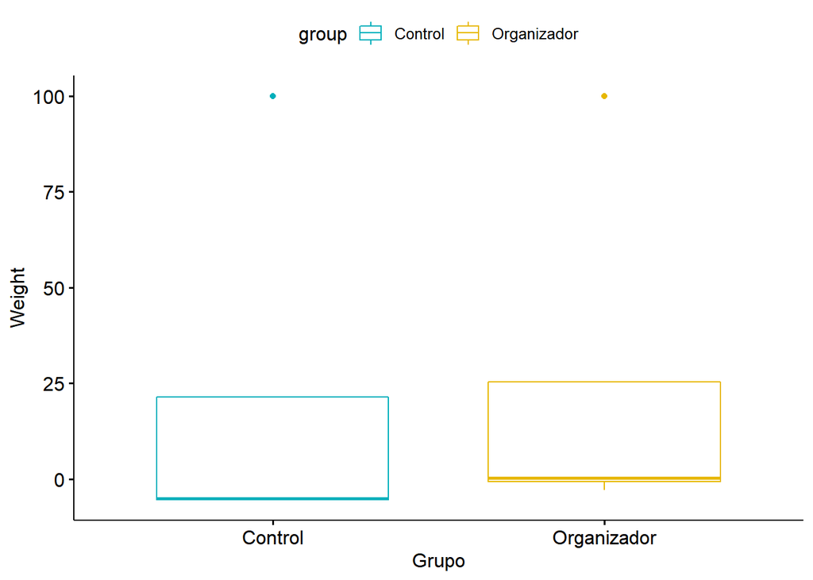

[1] “  
p-valor para dos años después 0.191266986878869” [1] “

## Incidencia de tuberculosis (por cada 100,000 personas)

### Comparación con un año antes

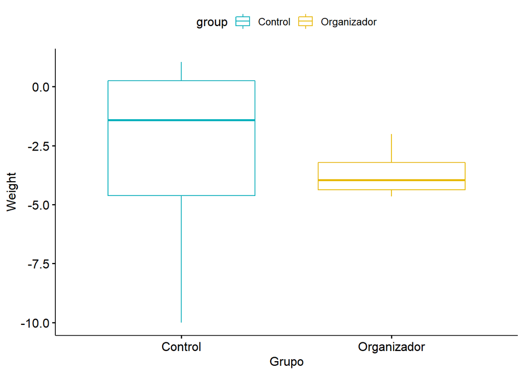

[1] “  
p-valor para un año antes 0.386476230771233” [1] “

### Comparación con un año después

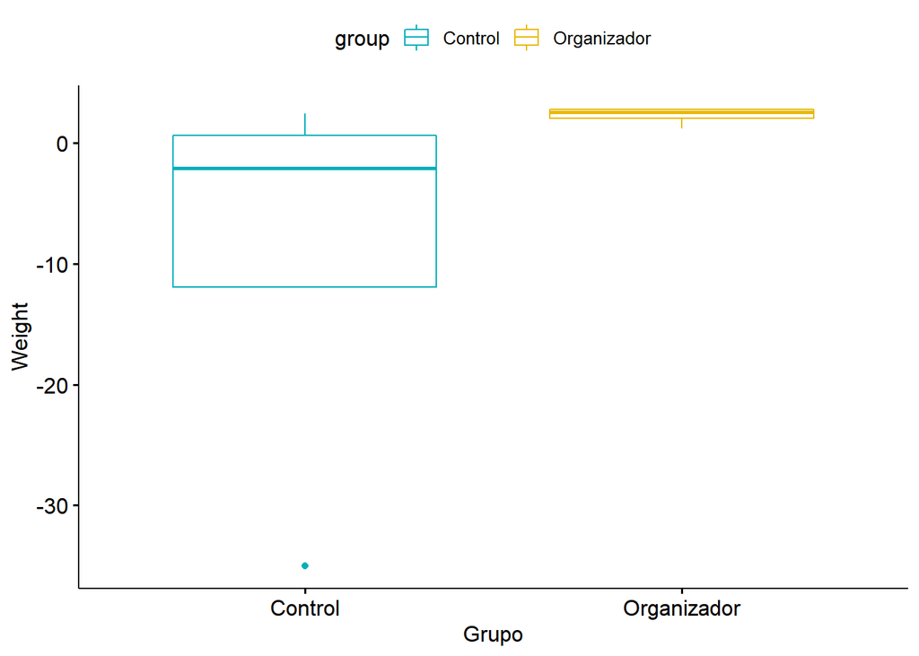

[1] “  
p-valor para un año después 0.0832645166635505” [1] “

### Comparación con dos años después

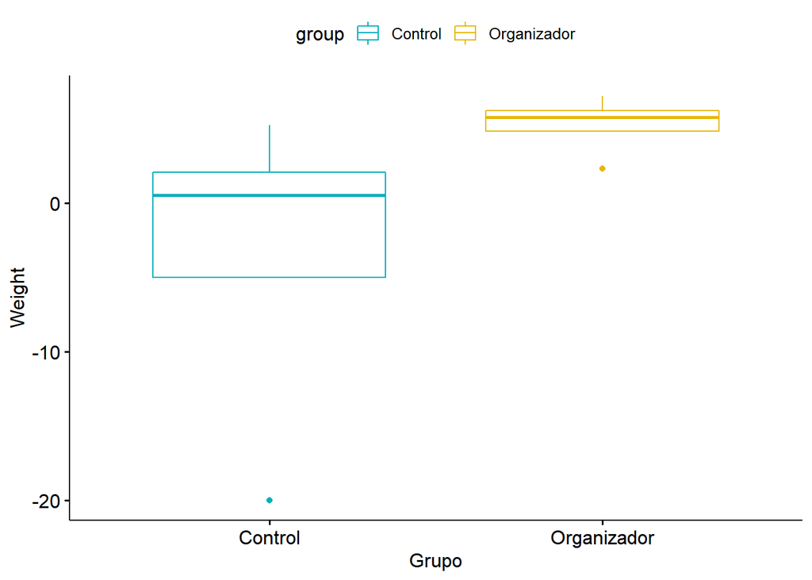

[1] “  
p-valor para dos años después 0.043308142810792” [1] “

## Desempleo, mujeres (% de la poblacion activa femenina) (estimacion modelado OIT)

### Comparación con un año antes

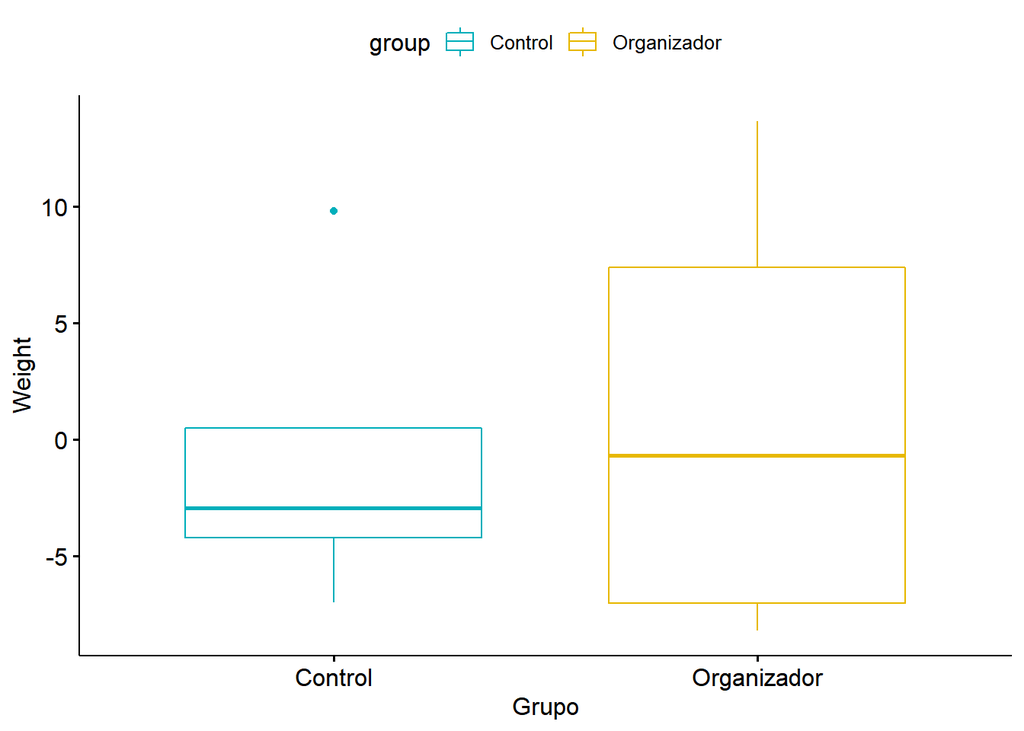

[1] “  
p-valor para un año antes 1” [1] “

### Comparación con un año después

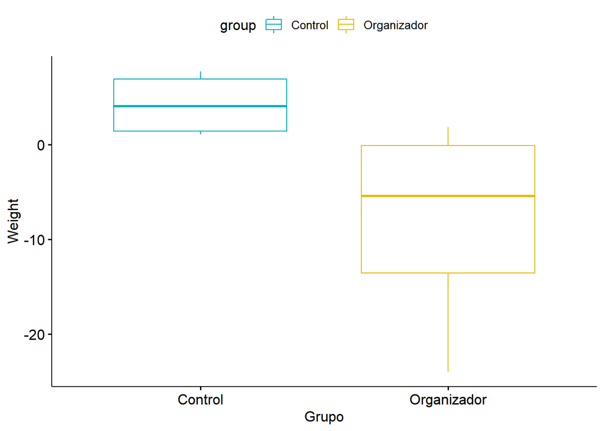

[1] “  
p-valor para un año después 0.0832645166635505” [1] “

### Comparación con dos años después

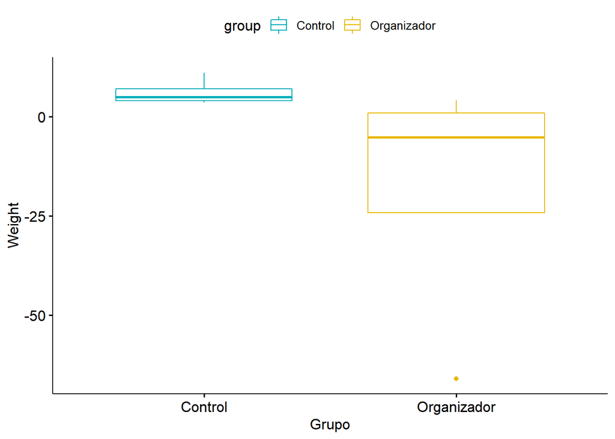

[1] “  
p-valor para dos años después 0.043308142810792” [1] “

## Desempleo, varones (% de la poblacion activa masculina) (estimacion modelado OIT)

### Comparación con un año antes

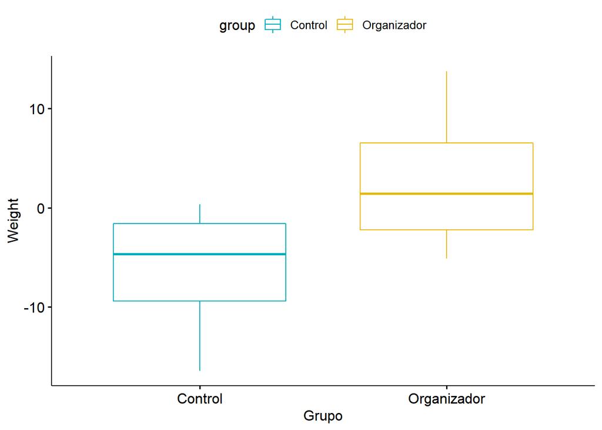

[1] “  
p-valor para un año antes 0.0346105575157074” [1] “

### Comparación con un año después

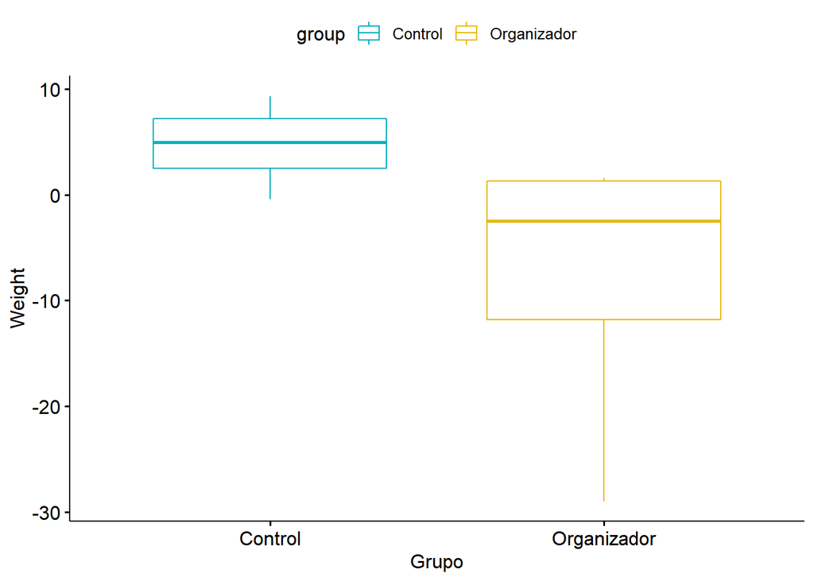

[1] “  
p-valor para un año después 0.0112298866529167” [1] “

### Comparación con dos años después

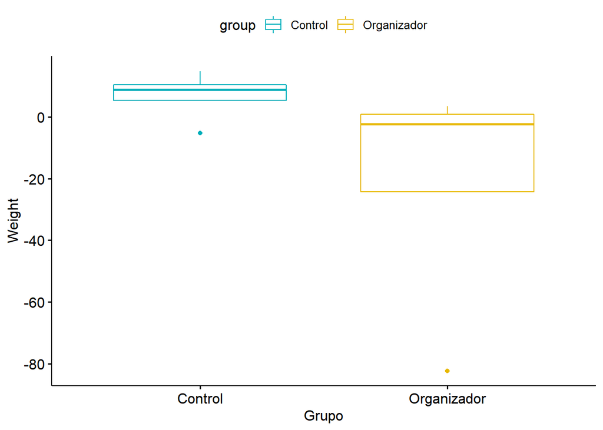

[1] “  
p-valor para dos años después 0.0346105575157074” [1] “

## Desempleo, total (% de la poblacion activa total) (estimacion modelado OIT)

### Comparación con un año antes

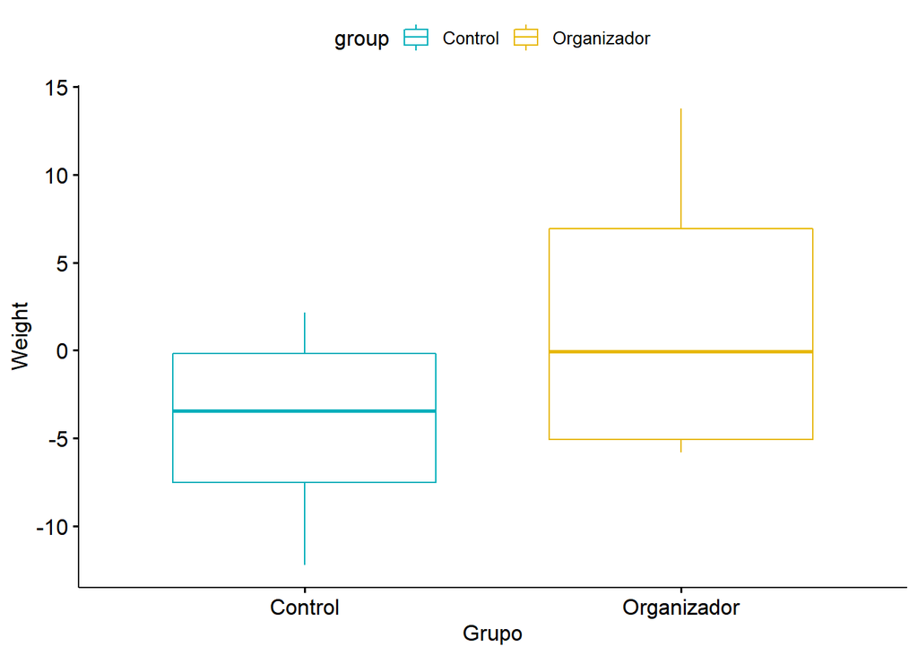

[1] “  
p-valor para un año antes 0.248213078989924” [1] “

### Comparación con un año después

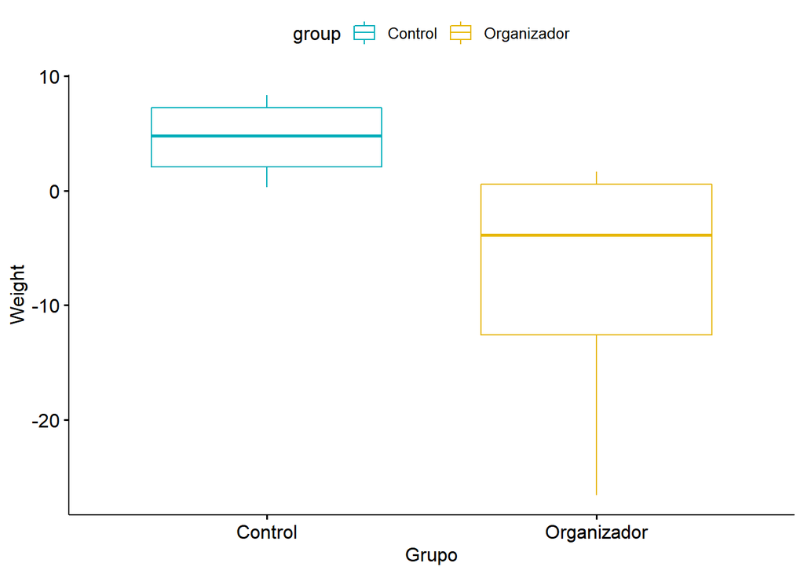

[1] “  
p-valor para un año después 0.043308142810792” [1] “

### Comparación con dos años después

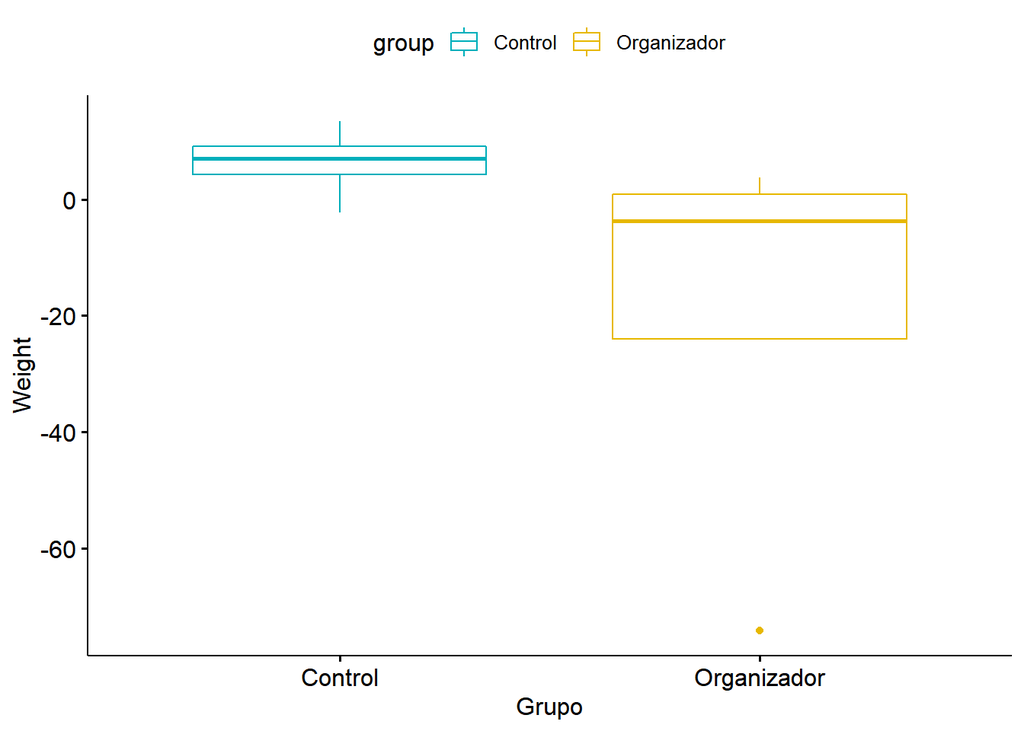

[1] “  
p-valor para dos años después 0.0832645166635505” [1] “

### Comparación con un año antes

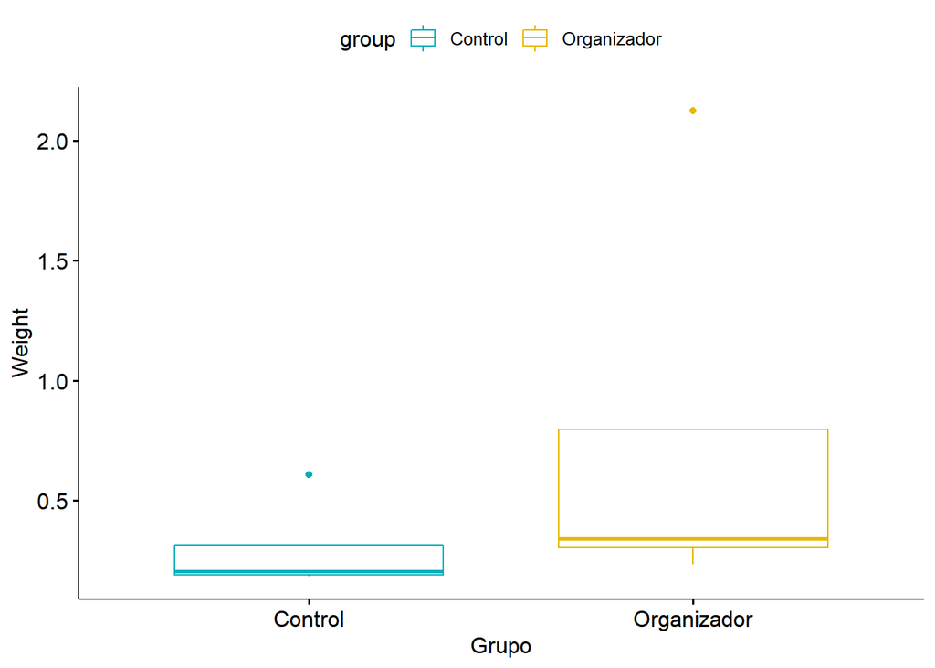

[1] “  
p-valor para un año antes 0.148914673178766” [1] “

### Comparación con un año después

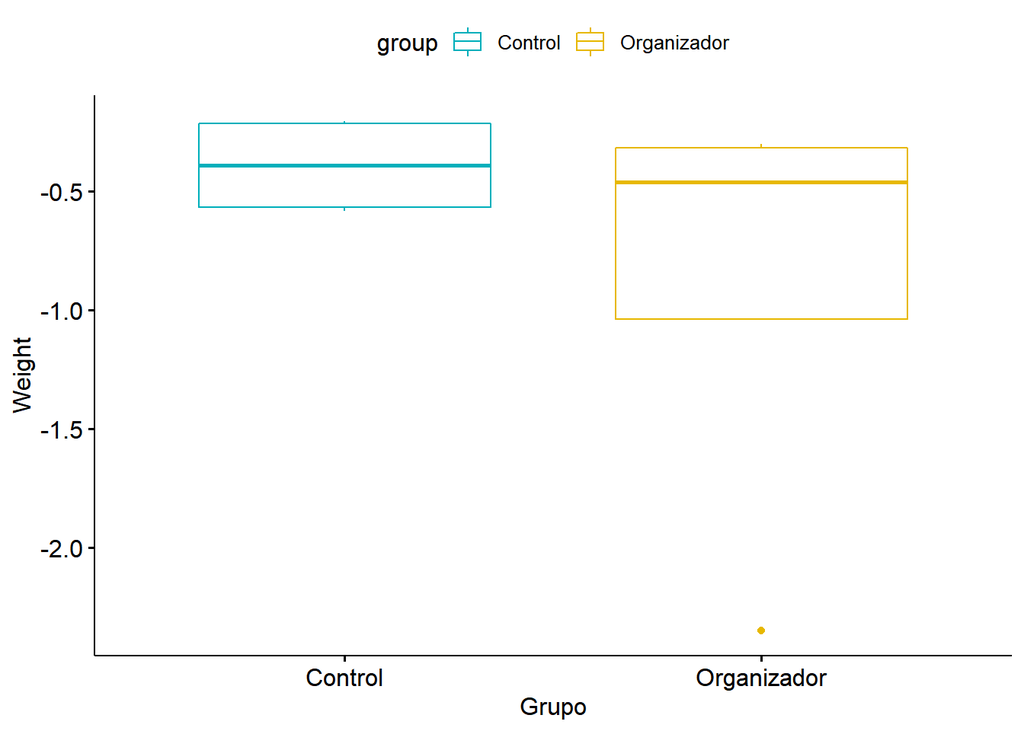

[1] “  
p-valor para un año después 0.248213078989924” [1] “

### Comparación con dos años después

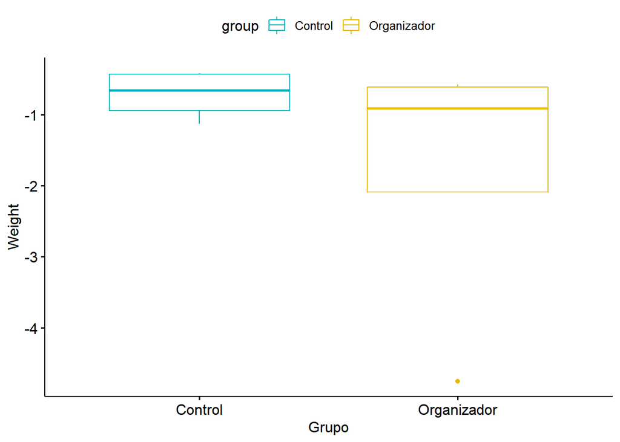

[1] “  
p-valor para dos años después 0.248213078989924” [1] “

## Poblacion de 65 aÃ±os de edad y mas, total

" [1] “

### Comparación con un año antes

"

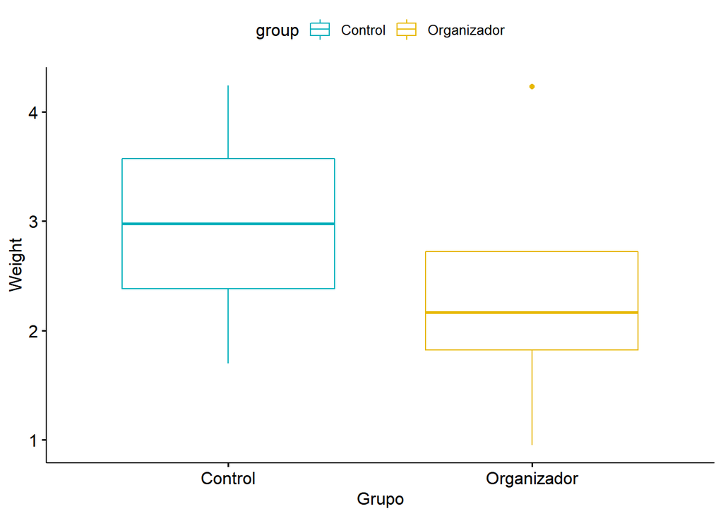

[1] “  
p-valor para un año antes 0.386476230771233” [1] “

### Comparación con un año después

"

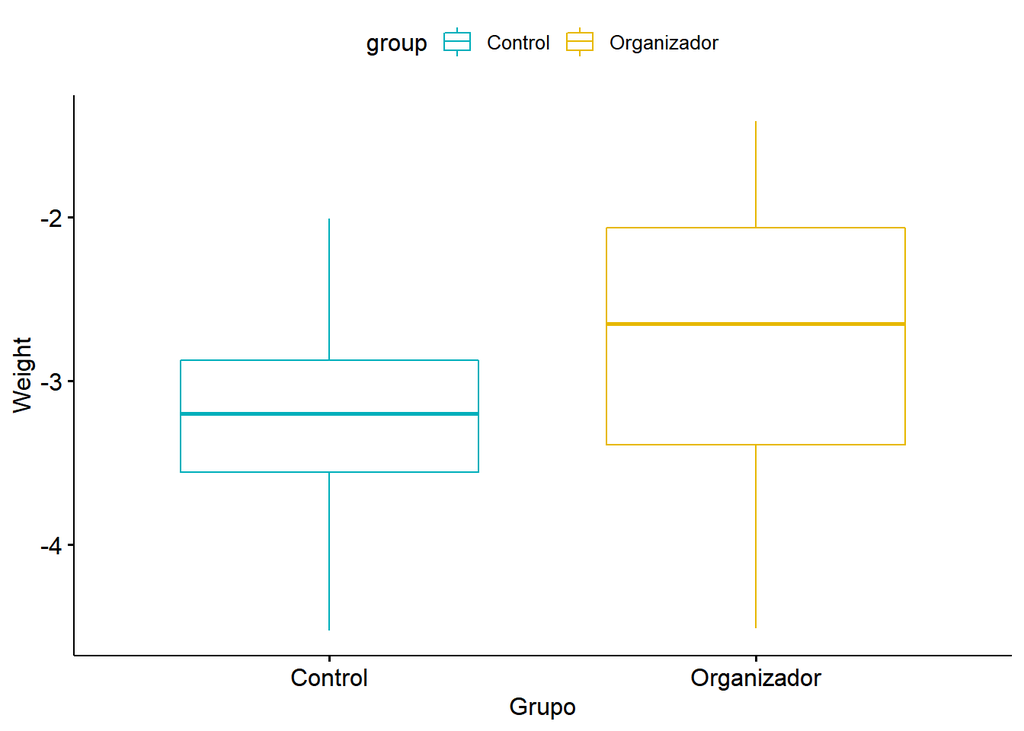

[1] “  
p-valor para un año después 0.386476230771233” [1] “

### Comparación con dos años después

"

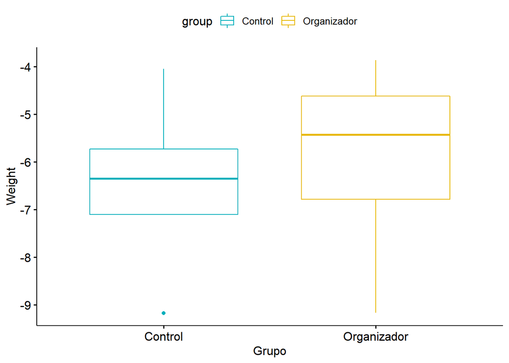

[1] “  
p-valor para dos años después 0.386476230771233” [1] “

## Turismo internacional, numero de arribos

" [1] “

### Comparación con un año antes

"

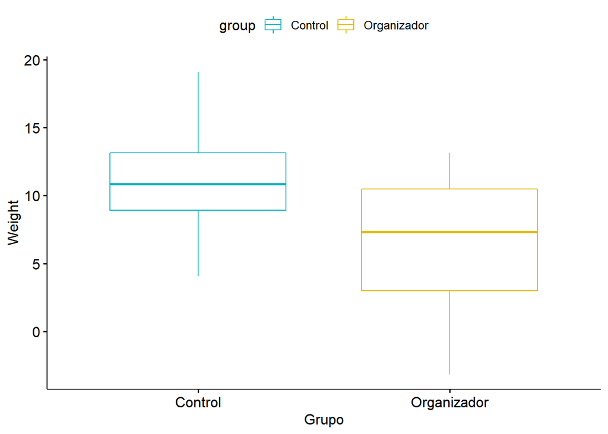

[1] “  
p-valor para un año antes 0.386476230771233” [1] “

### Comparación con un año después

"

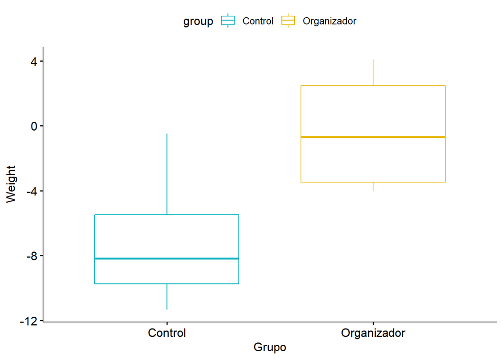

[1] “  
p-valor para un año después 0.0832645166635505” [1] “

### Comparación con dos años después

"

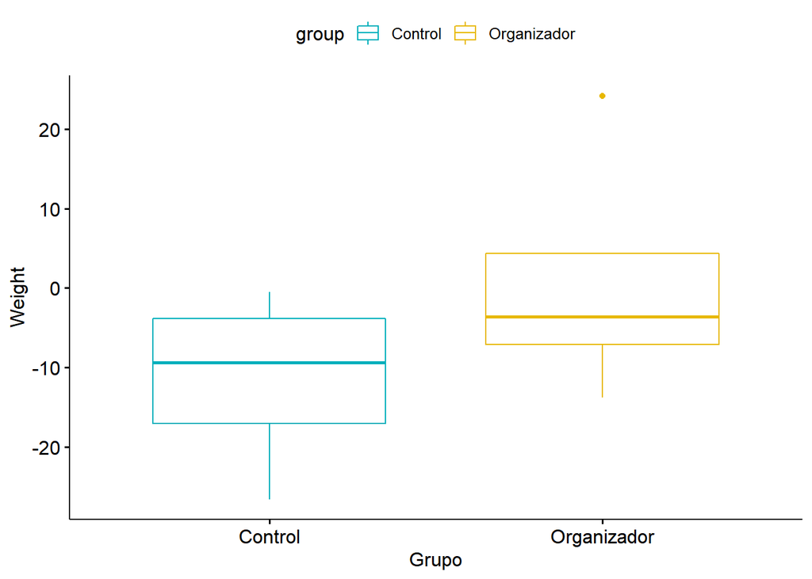

[1] “  
p-valor para dos años después 0.386476230771233” [1] “

## Turismo internacional, gastos (US$ a precios actuales)

" [1] “

### Comparación con un año antes

"

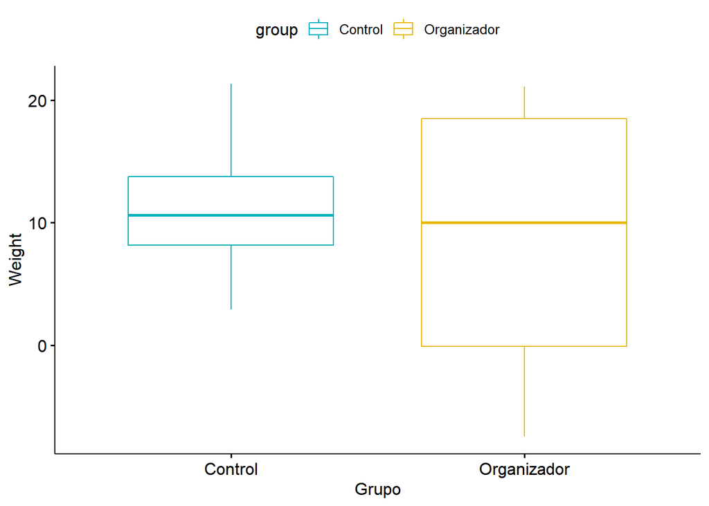

[1] “  
p-valor para un año antes 0.563702861650774” [1] “

### Comparación con un año después

"

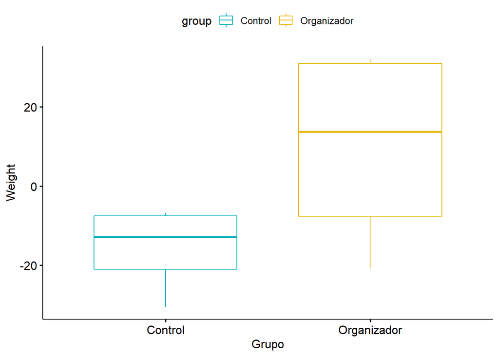

[1] “  
p-valor para un año después 0.148914673178766” [1] “

### Comparación con dos años después

"

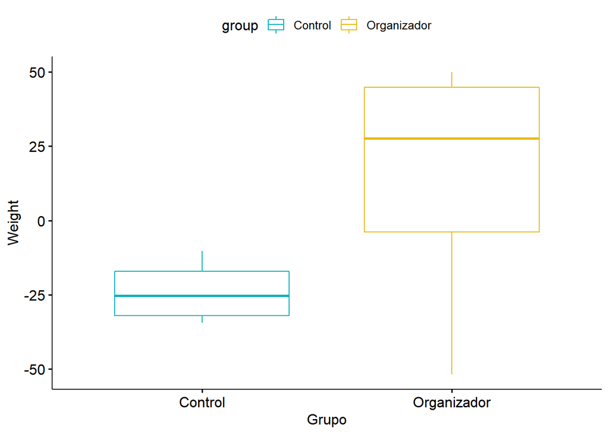

[1] “  
p-valor para dos años después 0.248213078989924” [1] “

## indice de valor de exportacion (2000 = 100)

" [1] “

### Comparación con un año antes

"

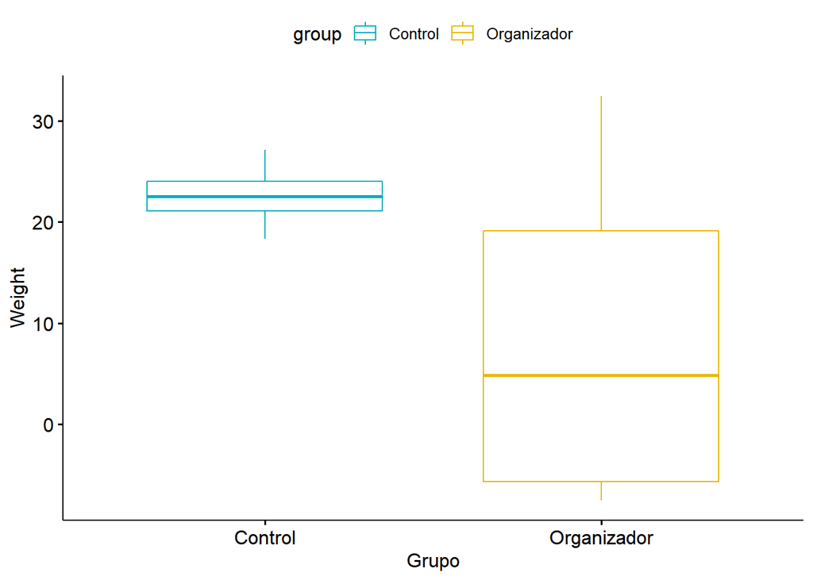

[1] “  
p-valor para un año antes 0.248213078989924” [1] “

### Comparación con un año después

"

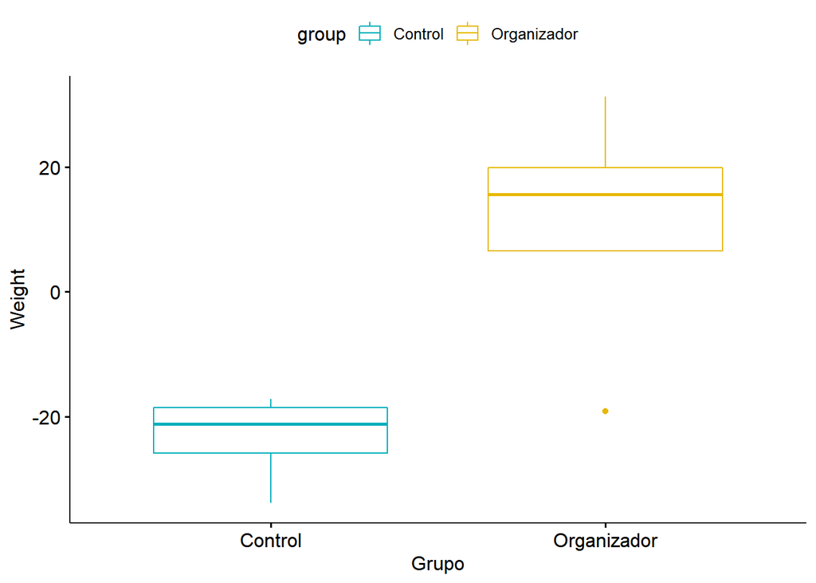

[1] “  
p-valor para un año después 0.0832645166635505” [1] “

### Comparación con dos años después

"

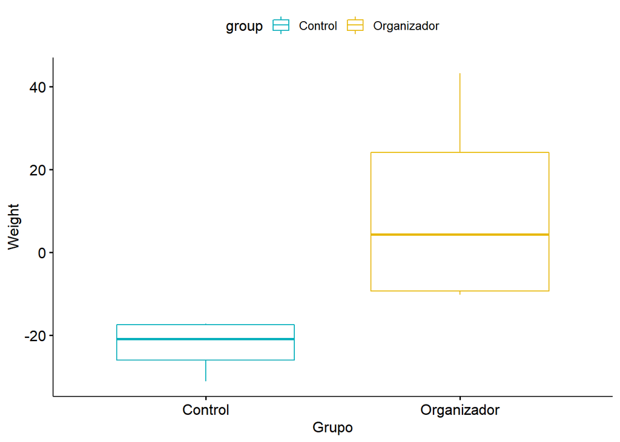

[1] “  
p-valor para dos años después 0.020921335337794” [1] “

## Exportaciones de productos de alta tecnologia (% de las exportaciones de productos manufacturados)

" [1] “

### Comparación con un año antes

"

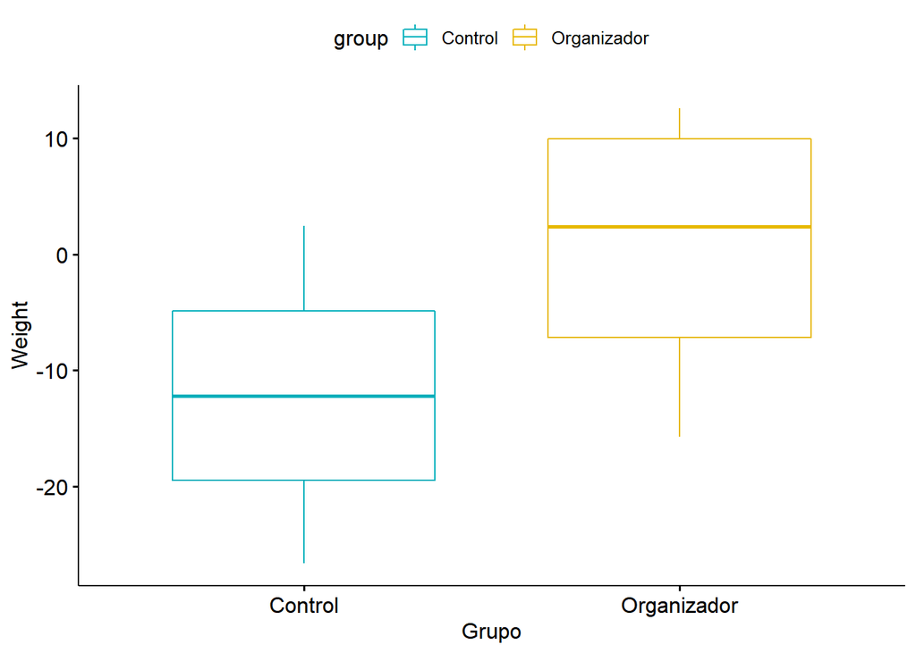

[1] “  
p-valor para un año antes 0.148914673178766” [1] “

### Comparación con un año después

"

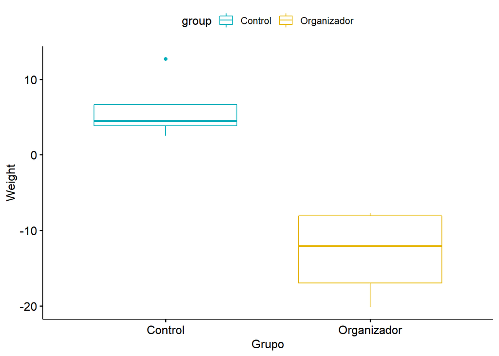

[1] “  
p-valor para un año después 0.020921335337794” [1] “

### Comparación con dos años después

"

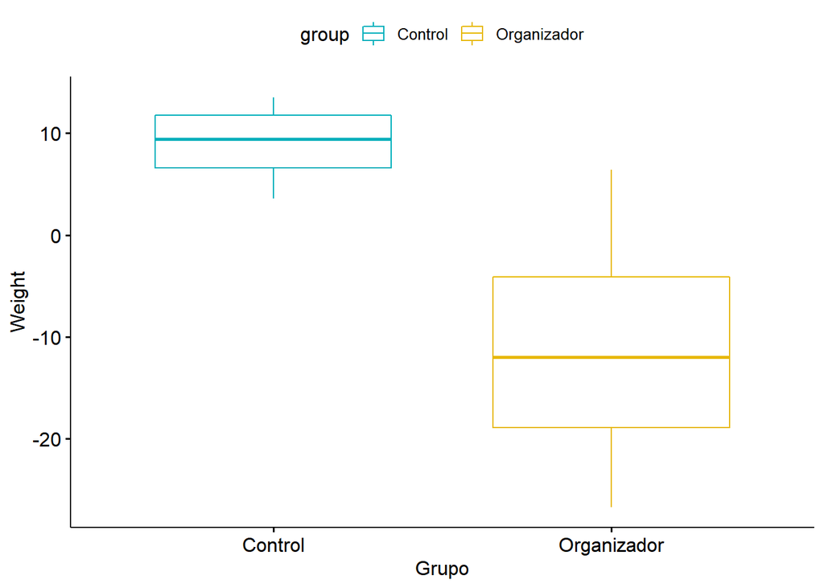

[1] “  
p-valor para dos años después 0.043308142810792” [1] “

## Brecha de pobreza a $1,90 por dia (2011 PPA) (%)

" [1] “

### Comparación con un año antes

"

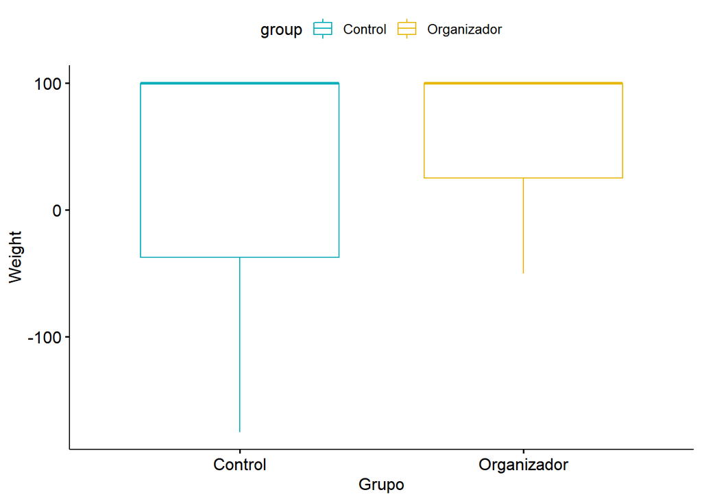

[1] “  
p-valor para un año antes 0.79625341473764” [1] “

### Comparación con un año después

"

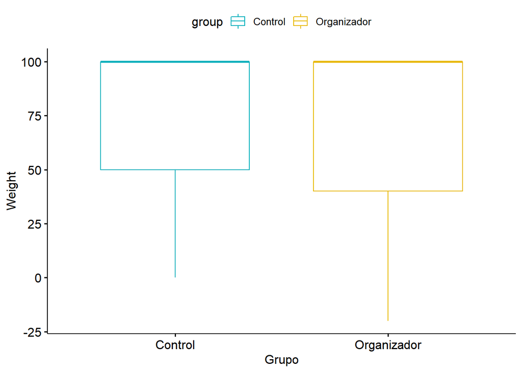

[1] “  
p-valor para un año después 0.79625341473764” [1] “

### Comparación con dos años después

"

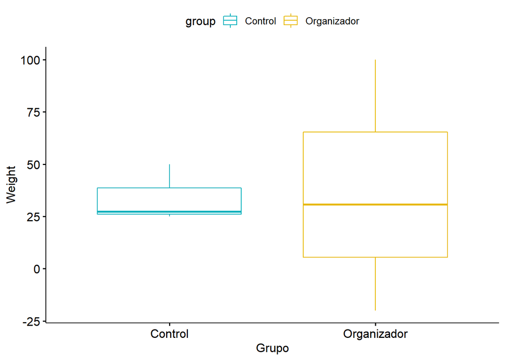

[1] “  
p-valor para dos años después 0.827259346562712”